# Hofmann experiment 2

2023-06-19

## Setting

- Objective: investigate the power of four competing designs, in assessing a mean shift bewteen distributions
- Hypotheses for each lineup are:
  - $H_0$: centers of the two groups are the smae
  - $H_a$: centers of teh blue group is shifted to the right (blue group is group 2)
- factors:
  - size of the shift between two distributions $d \in \{0.4, 0.6, 0.8, 1.0, 1.2\}$ (5 levels)
  - size of the larger group: $n_1 \in \{15, 45, 135\}$ (3 levels)
  - relative size of the second group: $r \in \{1/3, 2/3, 3/3\}$ (3 levels); $n_2 = r\cdot n_1$
  - 3 replicated data sets; sampled from exponential distributions with $\lambda_1 = 1$ and $\lambda_2 = 1/(d+1)$
  - 4 graph types: boxplots, density plots, histograms, dotplots

```r
d <- 0.4# size of the shift between distributions
n1 <- 15 # size of the fitst group of points
r <- 1/3 # ratio between n1 and n2
n2 <- r * n1
data1 <- rexp(n1, 1)
data2 <- rexp(n2, 1/(d + 1))
```

The authors associate a “difficulty” level with lineups from 1 to 9, using the $p$-value corresponding to the difference in means between the two groups in the simulated data sets:

```r
result <- t.test(data1, data2)
result
```

```
##
##  Welch Two Sample t-test
##
## data:  data1 and data2
## t = -0.66928, df = 5.3778, p-value = 0.531
## alternative hypothesis: true difference in means is not equal to 0
## 95 percent confidence interval:
##  -2.208332  1.280668
## sample estimates:
## mean of x mean of y
##  1.247536  1.711368
```

# Charts

Boxplot:

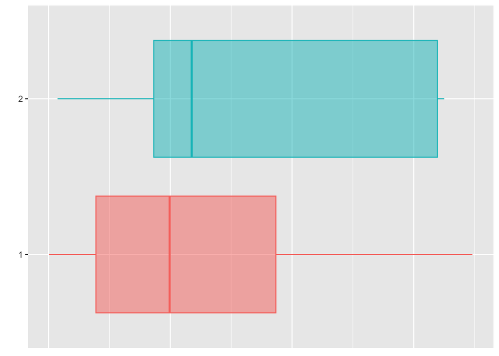

```r
# Combine the samples into one dataframe:
# combined data
c_df <- data.frame(
  Value = c(data1, data2),
  Group = factor(c(rep("1", n1), rep("2", n2)))
)
ggplot(c_df, aes(x = Value, y = Group, fill = Group, color = Group)) +
  geom_boxplot(alpha=0.5) +
  xlab("") +
  ylab("") +
  theme(legend.position = "none",
        axis.title.x=element_blank(),
        axis.text.x=element_blank(),
        axis.ticks.x=element_blank())
```

Using the `nullabor` package, we can generate a lineup graph. Also, based on figure 3 in the original picture, it is safe to assume that the task each participant saw was: In which plot is the blue group furthest to the right?

```r
d <- lineup(null_permute("Value"), c_df)
```

```
## decrypt("23eg MuPu NE KwWNPNwE 5F")
```

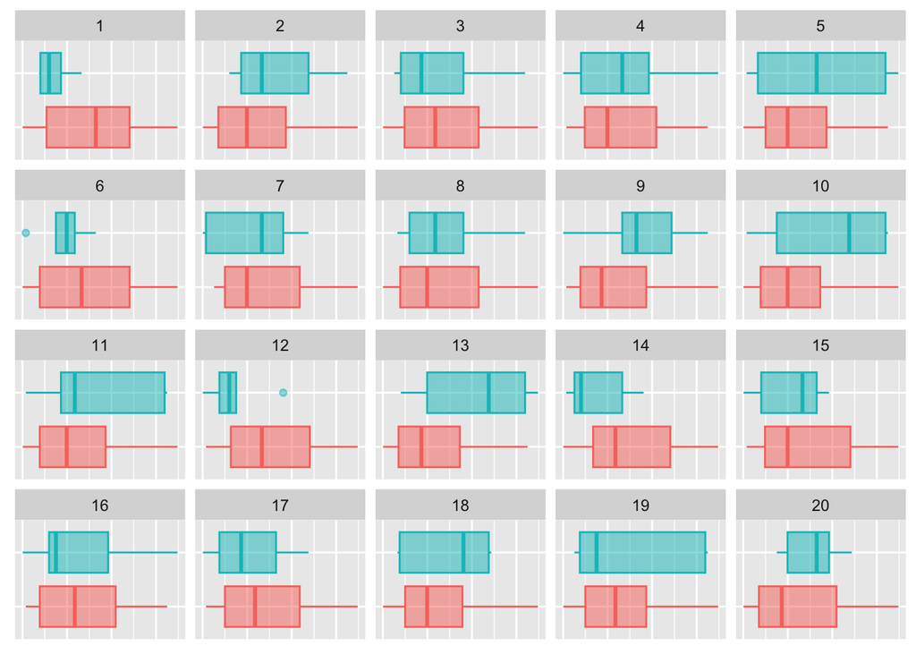

```r
ggplot(d, aes(x = Value, y = Group, fill = Group, color = Group)) +
  geom_boxplot(alpha=0.5) +
  facet_wrap(~ .sample) +
  xlab("") +
  ylab("") +
  theme(legend.position = "none",
        axis.title=element_blank(),
        axis.text=element_blank(),
        axis.ticks=element_blank())
```

The position of the true graph (i.e., the un-permutated one), is:

```r
attr(d, "pos") # position of actual graph
```

```
## [1] 11
```